# Course Intro

Lecture 1A

PUBHBIO 6250

## The Big Picture: Inference to a Population

**Overarching Goal:** Use **statistical inference** to draw conclusions about a **population** using data from a **sample**

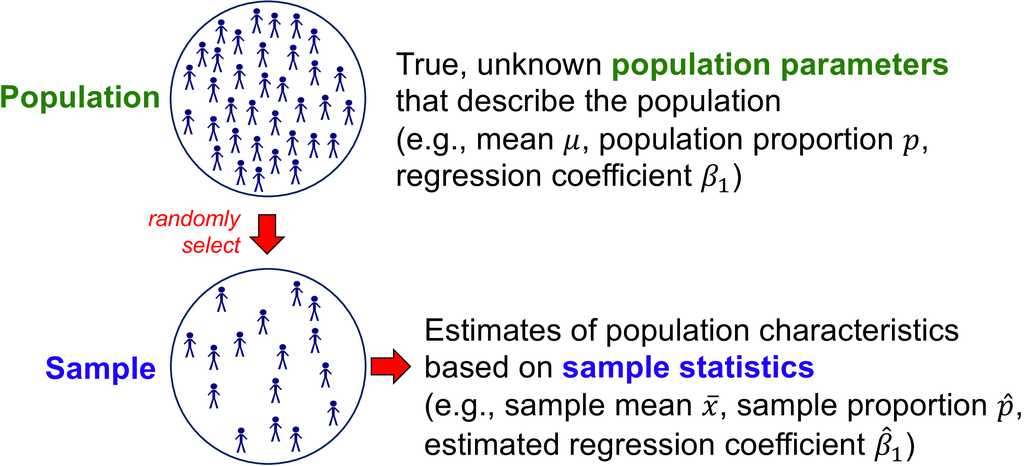

## Example: Linear Regression

Relationship between age $(X)$ and systolic blood pressure $(Y)$ *(fictitious data)*

**Full population** – true relationship:

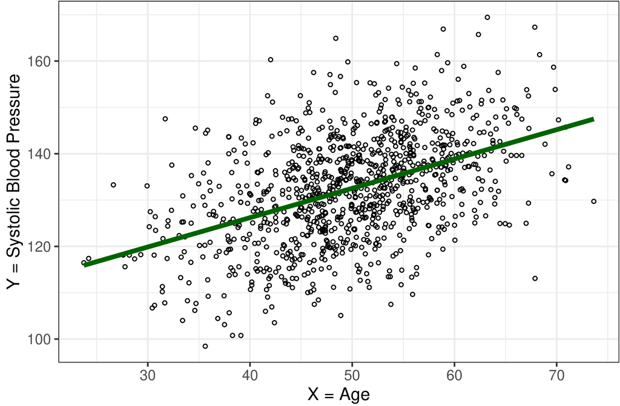

$\beta_{AGE} = 0.633$

**Sample** – estimate of relationship:

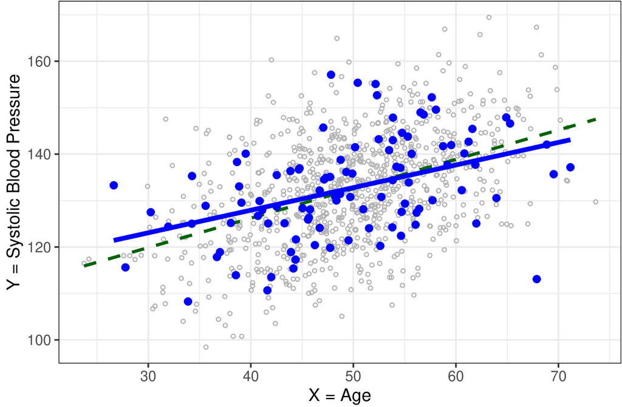

$\hat{\beta}_{AGE} = 0.49$, 95% CI: $(0.28, 0.69)$

## Focus of This Course

This course will focus on **regression methods**, expanding/building on what you have learned in previous courses

Topics we will cover include:

- Logistic regression
- Poisson regression
- Cox Proportional Hazards regression (survival analysis)
- Analysis of data from a complex sample survey, including regression methods

We assume you have a solid understanding of **linear regression** as a foundation, including familiarity with concepts used in regression such as **dummy variables for categorical predictors**, **interaction terms**, **confounding**, etc.

## Learning Objectives for This Course

1. Select the appropriate regression method for a specified outcome measurement
2. Construct a regression model to estimate a population parameter specified by the scientific question
3. Interpret results from a wide variety of regression models
4. Analyze data collected via a complex sample survey (probability sample)
5. Evaluate statistical methods and results presented in the public health and biomedical sciences literature (journal articles)

**By the end of this course, you will be able to:** Answer a specified research question by implementing the appropriate regression/analysis methods on a provided data set

## Structure of This Course

For each topic (e.g., logistic regression), learning activities are arranged as:

- First week – short recorded lectures, multiple choice quiz, computer lab
- Second week – short recorded lectures, multiple choice quiz, computer lab
- Third week – case study (journal article), data application

The lectures for each topic will come from **faculty experts in the area**

Additional weeks will include synthesis across topics and practice choosing the right analysis strategy for a given research question